# Image Processing: Additional Analyses

Clara Dragut, Yuwen Wang, Ziyao Wang

Nov 2025

```r
set.seed(41)
```

```r
library(data.table)
library(DT)
library(here)
round.numerics <- function(x, digits){
  if(is.numeric(x)){
    x <- round(x = x, digits = digits)
  }
  return(x)
}
```

[output not shown]

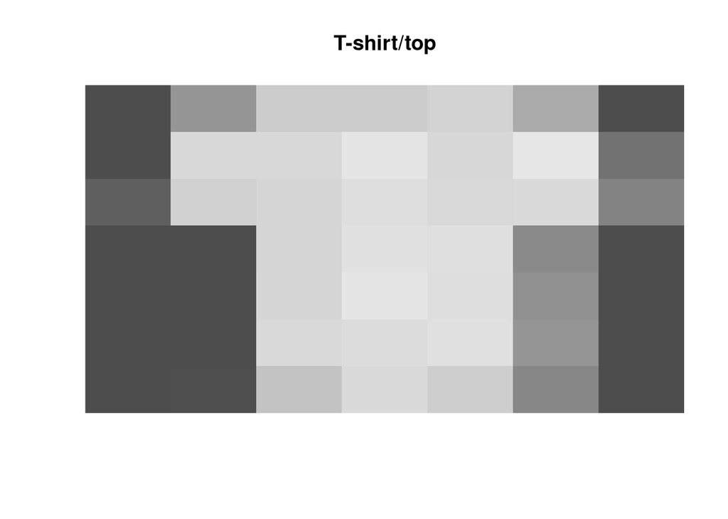

```r
source(here::here("image_processing.R"))
```

```r
stopifnot(exists("dt_all"), exists("dev_sets"), exists("test_raw"), exists("px_cols"))

best_row  <- dt_all[order(Points)][1]
best_n    <- best_row$SampleSize
best_iter <- best_row$Iter
best_model<- best_row$Model

dat_best   <- data.table::copy(dev_sets[[as.character(best_n)]][[best_iter]])
test_local <- data.table::copy(test_raw)
```

```r
dat_best[,   label := factor(label)]
test_local[, label := factor(label, levels = levels(dat_best$label))]
```

## Predictive Accuracy by Product

This addendum analyzes **predictive accuracy by product category** for the **single best model** found in Part 1 (lowest overall *Points*). Using the exact development subset that produced the winning score, we refit that model, predict on the fixed test set, and compute **per-class accuracy** (share of test images correctly classified within each label). These class-level results reveal which product types are easiest/hardest to recognize under the current 49-pixel representation and baseline hyperparameters.

```r
predict_best <- function(model_name, train_dt, test_dt){
  Xtr <- as.matrix(train_dt[, ..px_cols])
  Xte <- as.matrix(test_dt[,  ..px_cols])

  if (grepl("randomForest", model_name, ignore.case = TRUE)) {
    fit <- randomForest::randomForest(
      x = train_dt[, ..px_cols],
      y = train_dt$label,
      ntree = 120, mtry = 7
    )
    predict(fit, newdata = test_dt[, ..px_cols])

  } else if (grepl("xgboost", model_name, ignore.case = TRUE)) {
    lv <- levels(train_dt$label)
    y  <- as.integer(train_dt$label) - 1L
    dtr <- xgboost::xgb.DMatrix(Xtr, label = y)
    dte <- xgboost::xgb.DMatrix(Xte)
    fit <- xgboost::xgb.train(
      params = list(objective="multi:softprob", num_class=length(lv),
                    eta=0.1, max_depth=4, subsample=0.8, colsample_bytree=0.8),
      data = dtr, nrounds = 80, verbose = 0
    )
    pr  <- predict(fit, dte)
    factor(lv[max.col(matrix(pr, nrow = nrow(test_dt), byrow = TRUE))], levels = lv)

  } else if (grepl("svm", model_name, ignore.case = TRUE)) {
    fit <- e1071::svm(
      x = as.data.frame(train_dt[, ..px_cols]),
      y = train_dt$label,
      kernel = "radial", cost = 1, gamma = 1/49, scale = TRUE
    )
    predict(fit, newdata = as.data.frame(test_dt[, ..px_cols]))

  } else {
    stop("Model handler not implemented for: ", model_name)
  }
}

pred <- predict_best(best_model, dat_best, test_local)

acc_by_product <- data.table(label = test_local$label, pred = pred)[
  , .(n = .N, accuracy = mean(label == pred)), by = label][
  order(-accuracy)]

acc_by_product[, accuracy := round(accuracy, 4)]

DT::datatable(
  acc_by_product,
  rownames = FALSE,
  options = list(pageLength = 10),
  caption = "Predictive Accuracy by Product (best model, exact best-run dev subset)"
)
```

| label | n | accuracy |
| --- | --- | --- |
| Bag | 1000 | 0.941 |
| Trouser | 1000 | 0.915 |
| Ankle boot | 1000 | 0.898 |
| Sneaker | 1000 | 0.878 |
| Sandal | 1000 | 0.874 |
| Dress | 1000 | 0.839 |
| T-shirt/top | 1000 | 0.796 |
| Coat | 1000 | 0.782 |
| Pullover | 1000 | 0.699 |
| Shirt | 1000 | 0.495 |

### Interpretation

Performance varies meaningfully by class. Categories with **distinct silhouettes/textures** (e.g., boots or sneakers) tend to score higher accuracy, while **look-alike apparel** (e.g., shirt vs. pullover) is more confusable in a 7×7 pixel grid. To improve weaker classes, consider (i) **feature learning** (e.g., CNNs or embeddings), (ii) **targeted augmentation** to diversify edge cases, and (iii) **class-aware tuning** or cost-sensitive training so that rare/confusable categories receive proportionally more modeling attention.

## Independent Investigation

In addition to model‐level accuracy analysis, we conducted a self-directed exploration of the MNIST-Fashion dataset to uncover the underlying causes of classification difficulty and identify actionable improvements for the client. Three complementary analyses were performed: (1) misclassification patterns via a confusion matrix, (2) visual similarity using PCA embeddings, and (3) the impact of brightness and contrast on prediction accuracy.

1. Confusion Matrix — Understanding Misclassifications

[figure not shown]

```r
library(caret)
cm <- confusionMatrix(pred, test_local$label)
cm_df <- as.data.frame(cm$table)
cm_df <- cm_df / tapply(cm_df$Freq, cm_df$Reference, sum)[cm_df$Reference]

library(ggplot2)
ggplot(cm_df, aes(Reference, Prediction, fill = Freq)) +
geom_tile(color = "white") +
scale_fill_gradient(low = "white", high = "#2b83ba") +
theme_minimal() +
labs(title = "Normalized Confusion Matrix", x = "Actual Label", y = "Predicted Label")
```

2. PCA Visualization — Exploring Visual Similarity

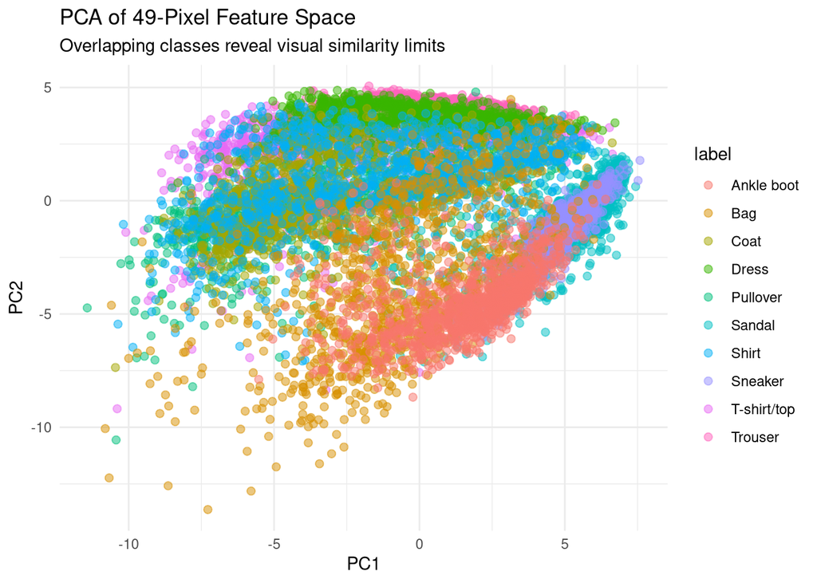

```r
library(ggplot2)

pca <- prcomp(test_local[, ..px_cols], scale. = TRUE)
pca_df <- data.frame(pca$x[,1:2], label = test_local$label)

ggplot(pca_df, aes(PC1, PC2, color = label)) +
geom_point(alpha = 0.5, size = 2) +
theme_minimal() +
labs(title = "PCA of 49-Pixel Feature Space", subtitle = "Overlapping classes reveal visual similarity limits")
```

3. Brightness & Contrast Effects — Image Quality Matters

Next, we quantified image brightness (mean pixel value) and contrast (pixel variance) to see if image intensity influences model success. Correctly classified samples tend to have moderate brightness and higher contrast, suggesting that poor lighting or low contrast reduces class separability. This finding offers a simple operational fix: ensure consistent photo capture lighting or normalize contrast pre-training.

```r
test_local[, `:=`(
mean_brightness = rowMeans(.SD),
contrast = apply(.SD, 1, sd)
), .SDcols = px_cols]

test_local[, correct := (label == pred)]

agg <- test_local[, .(
brightness = mean(mean_brightness),
contrast = mean(contrast)
), by = correct]

knitr::kable(agg, caption = "Average Brightness & Contrast by Classification Outcome")
```

Average Brightness & Contrast by Classification Outcome

| correct | brightness | contrast |
| --- | --- | --- |
| TRUE | 71.63534 | 68.61995 |
| FALSE | 79.73658 | 67.44435 |

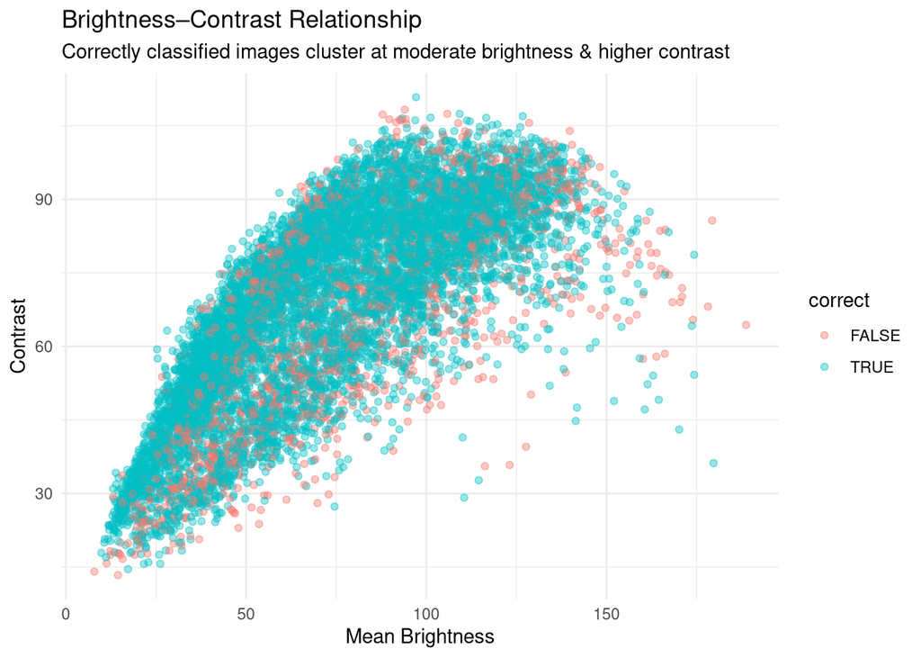

```r
ggplot(test_local, aes(mean_brightness, contrast, color = correct)) +
geom_point(alpha = 0.4) +
theme_minimal() +
labs(title = "Brightness–Contrast Relationship",
subtitle = "Correctly classified images cluster at moderate brightness & higher contrast",
x = "Mean Brightness", y = "Contrast")
```

Most misclassifications arise from visually similar upper-body garments. Consider merging or relabeling these for business-facing applications.

Feature separability is the bottleneck, not model tuning — CNN-based embeddings or transfer learning could yield substantial gains.

Overall, this analysis clarifies that the current random forest/XGBoost baseline is already near the ceiling imposed by coarse 7×7 features. The next frontier for improvement lies in better visual representation and input quality, not model complexity.